# Geopandas Practise_Section1

2020-04-14

# 01. Import the packages

#### Basic Packages

```python
## import pandas as pd
import geopandas as gpd
import numpy as np
import pandas as pd
import matplotlib.pyplot  as plt
from shapely.geometry import Point #turn latitude and longtitude into geographic points on the global
%matplotlib inline
```

```python
from shapely.geometry import Polygon
```

#### Geocoder packages

```python
from geopy.geocoders import Nominatim
from geopy.geocoders import GoogleV3
```

# 02. Importing shp files

### Shapefile contents

shp file is not one file, it includes several files with the same name but different file types.

Geopandas is made based on pandas, so the ways to read files are similar. But no matter what kind of file we are reading in Geopandas, we use **gpd.read_file**.

```python
cities = gpd.read_file('D:\ARCGIS\Covid-19 Cases in New Zealand\output\DHI_POINTS.shp')
```

```python
cities.head(2)
```

|  | OBJECTID_1 | OBJECTID | DHB2015_Co | DHB2015_Na | Shape_Leng | Shape_Le_1 | ORIG_FID | geometry |
| --- | --- | --- | --- | --- | --- | --- | --- | --- |
| 0 | 1 | 100 | 01 | Northland | 1.651929e+06 | 16.524423 | 0 | POINT (173.82591 -35.48993) |
| 1 | 2 | 100 | 02 | Waitemata | 9.273920e+05 | 9.301324 | 1 | POINT (174.54665 -36.56396) |

The last column is the geometry of the shp file data.  
The geometry includes: Point, Line, Ploygon

#### Plot the shp files

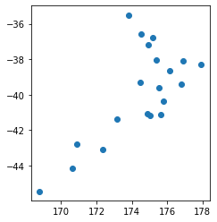

```python
cities.plot()
```

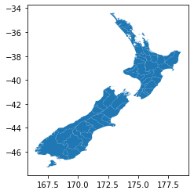

```python
Districts = gpd.read_file(r'D:\ARCGIS\mygeodata\nz_ta-polygon.shp')
Districts.plot()
```

```python
Districts.head(5)
```

|  | TA2016 | TA2016_NAM | AREA_SQ_KM | LAND_SQ_KM | rmapshaper | geometry |
| --- | --- | --- | --- | --- | --- | --- |
| 0 | 001 | Far North District | 6689.8397 | 6677.4102 | 0 | MULTIPOLYGON (((173.57980 -35.35020, 173.58690... |
| 1 | 002 | Whangarei District | 2711.7983 | 2711.7983 | 1 | MULTIPOLYGON (((174.70210 -35.95510, 174.71330... |
| 2 | 003 | Kaipara District | 3108.7123 | 3108.7123 | 2 | POLYGON ((173.76480 -35.60640, 173.75930 -35.6... |
| 3 | 011 | Thames-Coromandel District | 2207.0122 | 2207.0122 | 3 | MULTIPOLYGON (((175.92670 -37.06880, 175.92890... |
| 4 | 012 | Hauraki District | 1270.0486 | 1270.0486 | 4 | MULTIPOLYGON (((175.54000 -37.16870, 175.54210... |

#### Data Selection and treatment

Data selection and munipulation in Geopandas is same as Pandas, so it would be easy for those who are familiar with Pandas Packages.

###### Select the District with the area over 10000

```python
Districts[Districts.AREA_SQ_KM > 10000]
```

|  | TA2016 | TA2016_NAM | AREA_SQ_KM | LAND_SQ_KM | rmapshaper | geometry |
| --- | --- | --- | --- | --- | --- | --- |
| 44 | 053 | Marlborough District | 10470.4614 | 10457.6710 | 44 | MULTIPOLYGON (((174.10160 -41.53220, 174.10220... |
| 48 | 057 | Westland District | 11862.7155 | 11827.8208 | 48 | MULTIPOLYGON (((170.18810 -43.21380, 170.18780... |
| 62 | 073 | Southland District | 30198.4023 | 29552.3318 | 62 | MULTIPOLYGON (((167.39580 -47.26400, 167.39830... |

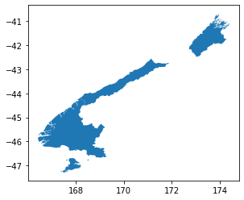

```python
Districts[Districts.AREA_SQ_KM > 10000].plot()
```

###### Select the District with the name starting with 'A'

```python
Districts[Districts.TA2016_NAM.str.startswith('A')]
```

|  | TA2016 | TA2016_NAM | AREA_SQ_KM | LAND_SQ_KM | rmapshaper | geometry |
| --- | --- | --- | --- | --- | --- | --- |
| 53 | 063 | Ashburton District | 6189.5196 | 6182.5534 | 53 | POLYGON ((172.19490 -43.90370, 172.18710 -43.9... |
| 65 | 076 | Auckland | 4940.8756 | 4939.8049 | 65 | MULTIPOLYGON (((175.16600 -36.90360, 175.16900... |

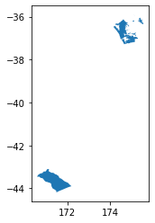

```python
Districts[Districts.TA2016_NAM.str.startswith('A')].plot()
```

### Write the info into files

#### Writing to shp files

```python
cities.to_file('D:\ARCGIS\Covid-19 Cases in New Zealand\output\DHI_POINTS_COPY.shp')
```

#### Writing to GeoJason

```python
cities.to_file('D:\ARCGIS\Covid-19 Cases in New Zealand\output\DHI_POINTS.geojson', driver = 'GeoJSON')
```

# 03. Opening CSV files with geopandas

1. open up the csv with pandas
2. We'll take lat/lon feed it to shapely, which creates a Point
3. we will use original dataframe and geometry infomation to make geodataframe for Geopandas
4. tell the new geodataframe that coords are latitude and longitude

###### read out the csv files

```python
df = pd.read_csv('Chicago_Public_Schools_-_Progress_Report_Cards__2011-2012-v3.csv')
df.head(2)
```

|  | School ID | NAME_OF_SCHOOL | Elementary, Middle, or High School | Street Address | City | State | ZIP Code | Phone Number | Link | Network Manager | ... | Freshman on Track Rate % | X_COORDINATE | Y_COORDINATE | Latitude | Longitude | COMMUNITY_AREA_NUMBER | COMMUNITY_AREA_NAME | Ward | Police District | Location |
| --- | --- | --- | --- | --- | --- | --- | --- | --- | --- | --- | --- | --- | --- | --- | --- | --- | --- | --- | --- | --- | --- |
| 0 | 610038 | Abraham Lincoln Elementary School | ES | 615 W Kemper Pl | Chicago | IL | 60614 | (773) 534-5720 | http://schoolreports.cps.edu/SchoolProgressRep... | Fullerton Elementary Network | ... | NDA | 1171699.458 | 1915829.428 | 41.924497 | -87.644522 | 7 | LINCOLN PARK | 43 | 18 | (41.92449696, -87.64452163) |
| 1 | 610281 | Adam Clayton Powell Paideia Community Academy ... | ES | 7511 S South Shore Dr | Chicago | IL | 60649 | (773) 535-6650 | http://schoolreports.cps.edu/SchoolProgressRep... | Skyway Elementary Network | ... | NDA | 1196129.985 | 1856209.466 | 41.760324 | -87.556736 | 43 | SOUTH SHORE | 7 | 4 | (41.76032435, -87.55673627) |

2 rows × 78 columns

###### Select the column data we need

```python
df2 = df.loc[:,['NAME_OF_SCHOOL','City','Latitude','Longitude' ]]
```

```python
df2.head()
```

|  | NAME_OF_SCHOOL | City | Latitude | Longitude |
| --- | --- | --- | --- | --- |
| 0 | Abraham Lincoln Elementary School | Chicago | 41.924497 | -87.644522 |
| 1 | Adam Clayton Powell Paideia Community Academy ... | Chicago | 41.760324 | -87.556736 |
| 2 | Adlai E Stevenson Elementary School | Chicago | 41.747111 | -87.731702 |
| 3 | Agustin Lara Elementary Academy | Chicago | 41.809757 | -87.672145 |
| 4 | Air Force Academy High School | Chicago | 41.828146 | -87.632794 |

```python
Point(-78,40)
```

#### Creating shapely Points from latitude and longtitude

```python
points = df2.apply(lambda row:Point(row.Longitude,row.Latitude), axis =1)# Attention: axis =1
points.head()
```

```
0    POINT (-87.64452163 41.92449696)
1    POINT (-87.55673627 41.76032435)
2    POINT (-87.73170248 41.74711093)
3      POINT (-87.6721446 41.8097569)
4    POINT (-87.63279369 41.82814609)
dtype: object
```

#### Making a geodataframe by dataframe and geo point information

```python
schools = gpd.GeoDataFrame(df2,geometry = points)
schools.crs = {'init':'epsg:4326'}   #project system
schools.head(2)
```

|  | NAME_OF_SCHOOL | City | Latitude | Longitude | geometry |
| --- | --- | --- | --- | --- | --- |
| 0 | Abraham Lincoln Elementary School | Chicago | 41.924497 | -87.644522 | POINT (-87.64452 41.92450) |
| 1 | Adam Clayton Powell Paideia Community Academy ... | Chicago | 41.760324 | -87.556736 | POINT (-87.55674 41.76032) |

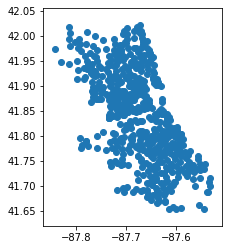

```python
schools.plot()
```

# 04. What is a Coordinate Reference Systems

### Coordinate Reference Systems Geographic Coordinate Systems

Ellipsoid - shape of the earth  
Datum - where is the ellipsoid goes

http://epsg.io/ to get the EPSG No. for certain address  
EPSG standards for European petroleum survey group

WGS84 -- EPSG:4326

NAD83 -- EPSG:4269

GDA94 -- EPSG:4939

IAU codes

# 05. Customizing map projections in geopandas

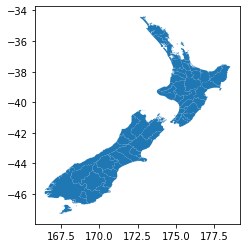

```python
Districts.plot()
```

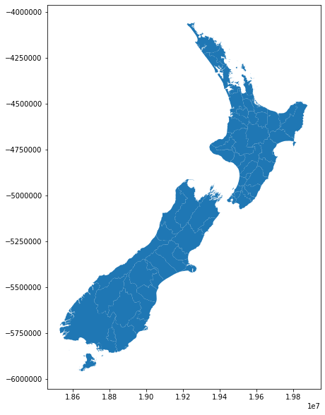

```python
Districts.to_crs({'proj':'merc'}).plot(figsize = (10,10))
```

#### We can see although the shape is still similar, the X,Y axes are different since the coordinate system has changed.

# 06. Customizing basic map styles with geopandas

pass parameter to .plot work with the ax variable

```
(165.81877500000002, 179.184325, -47.934870000000004, -33.747730000000004)
```

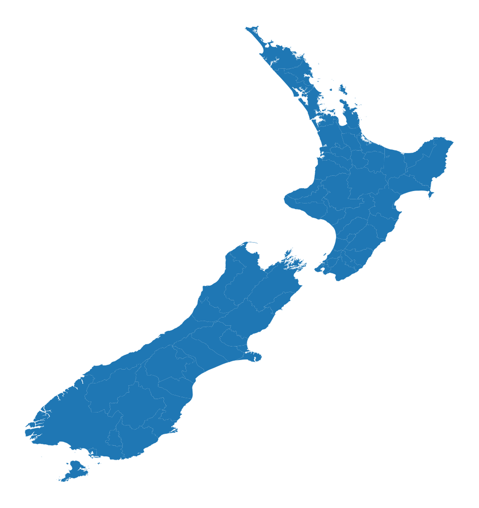

```python
ax = Districts.plot(figsize = (20,20))
ax.axis('off')
```

coloring shape

1.fill - inside part

1. strike/line/edge - outline

```
(165.81877500000002, 179.184325, -47.934870000000004, -33.747730000000004)
```

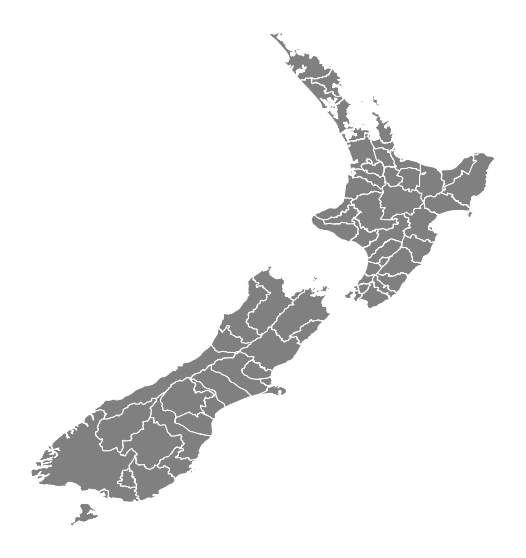

```python
ax = Districts.plot(figsize = (10,10), color = 'grey', edgecolor = 'white')
ax.axis('off')
```

```
(165.81877500000002, 179.184325, -47.934870000000004, -33.747730000000004)
```

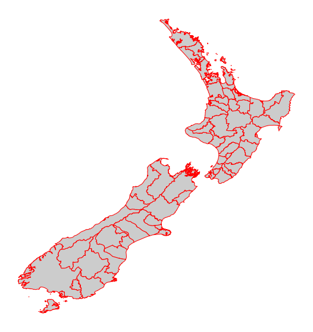

```python
ax = Districts.plot(figsize = (10,10), color = '#CCCCCC', edgecolor = '#FF0000')
ax.axis('off')
```

```
(168.32748359957623,
 178.38357246311102,
 -45.94570795960331,
 -34.986255336266005)
```

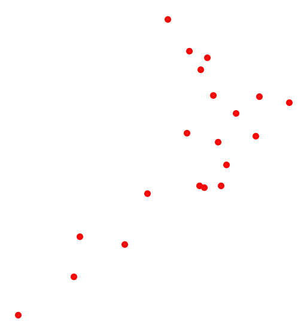

```python
ax = cities.plot(figsize = (10,10), color = '#CCCCCC', edgecolor = '#FF0000', linewidth = 5)
ax.axis('off')
```

```
(165.81877500000002, 179.184325, -47.934870000000004, -33.747730000000004)
```

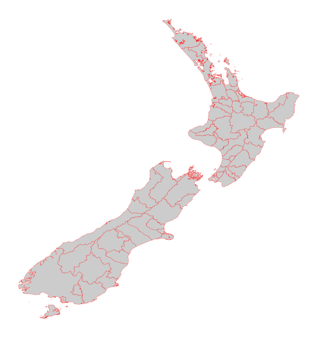

```python
ax = Districts.plot(figsize = (10,10), color = '#CCCCCC', edgecolor = '#FF0000', linewidth = 0.25)
ax.axis('off')
```

```python
Districts.head()
```

|  | TA2016 | TA2016_NAM | AREA_SQ_KM | LAND_SQ_KM | rmapshaper | geometry |
| --- | --- | --- | --- | --- | --- | --- |
| 0 | 001 | Far North District | 6689.8397 | 6677.4102 | 0 | MULTIPOLYGON (((173.57980 -35.35020, 173.58690... |
| 1 | 002 | Whangarei District | 2711.7983 | 2711.7983 | 1 | MULTIPOLYGON (((174.70210 -35.95510, 174.71330... |
| 2 | 003 | Kaipara District | 3108.7123 | 3108.7123 | 2 | POLYGON ((173.76480 -35.60640, 173.75930 -35.6... |
| 3 | 011 | Thames-Coromandel District | 2207.0122 | 2207.0122 | 3 | MULTIPOLYGON (((175.92670 -37.06880, 175.92890... |
| 4 | 012 | Hauraki District | 1270.0486 | 1270.0486 | 4 | MULTIPOLYGON (((175.54000 -37.16870, 175.54210... |

```
(165.81877500000002, 179.184325, -47.934870000000004, -33.747730000000004)
```

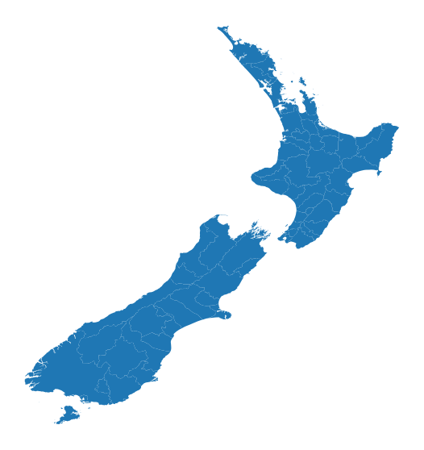

```python
ax = Districts.plot(figsize = (10,10))
ax.axis('off')
```

```
(165.81877500000002, 179.184325, -47.934870000000004, -33.747730000000004)
```

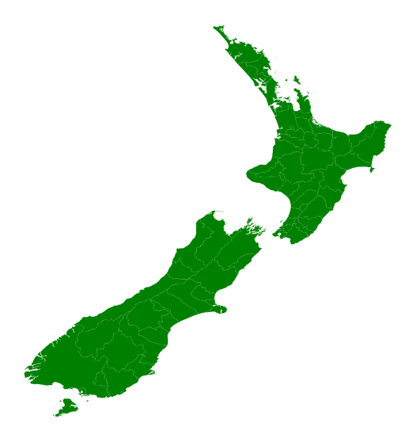

```python
ax = Districts.plot(figsize = (10,10), color = 'green')
ax.axis('off')
```

```
(165.81877500000002, 179.184325, -47.934870000000004, -33.747730000000004)
```

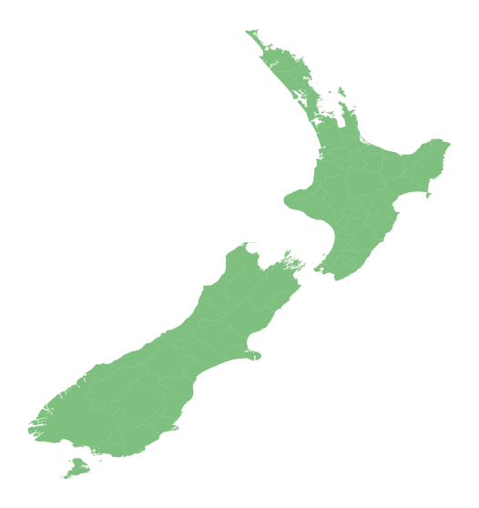

```python
ax = Districts.plot(figsize = (10,10), color = 'green',  markersize =100 ,alpha =0.5)
ax.axis('off')
```

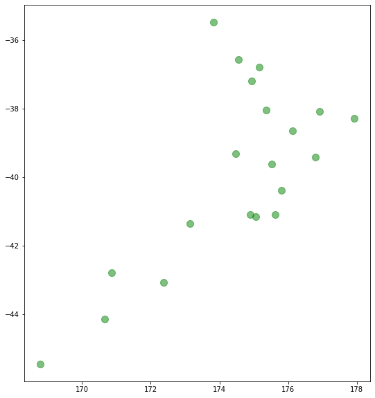

```python
ax = cities.plot(figsize = (10,10), color = 'green',  markersize =100 ,alpha =0.5)
```

```
(-42, -36)
```

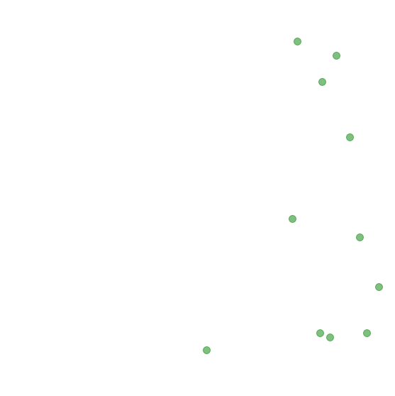

```python
ax = cities.plot(figsize = (10,10), color = 'green',  markersize =100 ,alpha =0.5)
ax.axis('off')
ax.set_xlim([170,176])
ax.set_ylim([-42,-36])
```

# Reference:

https://www.youtube.com/watch?v=JN35I8EYD4M&list=PLewNEVDy7gq3DjrPDxGFLbHE4G2QWe8Qh&index=9

https://geopandas.org/

http://epsg.io/

https://catalogue.data.govt.nz/dataset?res_format=GeoJSON

[figure not shown]

My name is Ford(Fan) Yang and this is my blog.  
I am a civil engineer with strong interest in data analysis.  
This blog is to make a record for what I am doing.  
I currently live and work in New Zealand, hit me up if you are in the region.